# 演算法 3：連結與換算

這是六份演算法教學的第三份。 前兩份做出校準（01_calibration）和分數（02_scoring）。 這一份把兩條量尺接起來，再把分數換到另一條量尺上。

你會學到：

- 連結的「點」是什麼：兩次校準的共同步驟，或錨題。
- mean/sigma 線怎麼算，為什麼先篩一次點。
- 連結誤差怎麼從「整題重抽」得到。
- 分數怎麼換算（`kits_convert()`），換算後的 `se_link`、`se_total` 怎麼來。
- 為什麼要把斜率和 1 比，以及接到 D 時的 domain check。

你需要：

- R 和 kits 0.24.2，以及 dplyr、tidyr、purrr、tibble、ggplot2。
- 知道 `kits_item()` 的門檻（`thr`）是什麼（01_calibration）。
- 知道 `kits_subj()` 的 $\theta$ 和 SE 是什麼（02_scoring）。

每一節都照同樣的順序走：這一步要做什麼 → 公式（排好的數學式，下面是可以一鍵複製的 LaTeX）→ 用示範資料手算 → 用 kits 的兩層函數再算一次 → 教學程式在哪一段。 `kits_` 的步驟會檢查、會記下量尺；`algo_` 的積木只有算法。 每次都用 `identical()` 對答案；只有浮點運算的順序不同時，才用 `all.equal()`，並寫出容許誤差。

連結本身沒有模型可以寫：它是封閉解（平均、SD、重抽），全部用 base R。 所以這一份不用 RTMB；模型的部分在 kits 的模型。

## 0 準備

### 0.1 這個算法有幾步

`kits_algorithm()` 用三十行左右說出一個算法：幾步、每步一條式子、哪些函數做這些步驟、文獻、教學程式。 被移除的 `kits_equations()`、`kits_code()` 給的東西，現在分成兩半：短的在這裡，詳細的在這份教學。

```r
kits_algorithm("link")
```

```
#> <kits_algorithm> link: a link: mean/sigma with one round of screening, and the linking error
#> Steps:
#>   1. Points: common steps of two calibrations, or pass step s of the anchors
#>        (from_j, to_j) = (thr_ik, thr_ik)  or  (thr_is, τ_i), τ = the GSED difficulty
#>   2. mean/sigma line on all points (A = slope, B = intercept)
#>        A = SD(to) / SD(from),  B = mean(to) − A mean(from)
#>   3. One round of screening, then the line again on the kept points
#>        e_j = to_j − (B0 + A0 from_j);  drop j if |e_j| > cut SD(e)
#>   4. Linking error: R resamples of whole items, the screening redone in each
#>        SE(B) = SD_r(B_r),  SE(A) = SD_r(A_r),  Cov(A, B) over the resamples
#>   5. Linking error at theta (a chain of links adds up the same way)
#>        SE_link(θ) = √(Var(B) + θ² Var(A) + 2θ Cov(A, B))
#>   6. Domain check: one slope shared by the domains d, one intercept each
#>        A_s = √(Σ (to − mean_d to)² / Σ (from − mean_d from)²),  B_d = mean_d to − A_s mean_d from
#> Components:
#>   pts <- kits_link_points(from, to)                          # from, to: two kits_item()
#>   pts |> kits_link_screen(cut = 2) |> kits_link_line() |> kits_link_error(n_boot = 200)
#>   screen <- algo_screen(pts$from, pts$to, pts$item, cut = 2)
#>   screen |> algo_mean_sigma()                                # the line: B, A
#>   screen |> algo_link_error(n_boot = 200)                    # SE(B), SE(A)
#>   algo_line(link, theta)                                     # new = B + A x old
#> References:
#>   Marco, G. L. (1977). Journal of Educational Measurement, 14, 139-160.
#>   Kolen, M. J., & Brennan, R. L. (2014). Test equating, scaling, and linking (3rd ed.). Springer.
#>   Weber, A. M., Rubio-Codina, M., Walker, S. P., et al. (2019). BMJ Global Health, 4, e001724.
#> Read more:
#>   tutorial_algorithms/03_linking.html
#>   system.file("scripts", "link.R", package = "kits"), parts: points, line, error, domains, slope, rules
```

### 0.2 示範資料：三個校準

示範資料是模擬的（`?kitm03`），沒有真實孩子的資料。 作答是長的表：一列是一個人次答一題（`visit_id`、`item_id`、`item_score`，加上月齡等欄）。 `kits_item()` 直接吃這種表。

```r
lan03 <- filter(kitm03$responses, domain == "lan")
motor03 <- filter(kitm03$responses, domain == "motor")
lan36 <- filter(kitm36$responses, domain == "lan")
c(lan03 = nrow(lan03), motor03 = nrow(motor03), lan36 = nrow(lan36))
```

```
#>   lan03 motor03   lan36
#>   58339  153458   39055
```

三個校準，各有自己的量尺標籤。 標籤讓 kits 知道一個分數在哪一條量尺上，換錯了會停下來。

```r
item03 <- kits_item(lan03, scale = "lan M03")
item_motor <- kits_item(motor03, scale = "motor M03")
item36 <- kits_item(lan36, scale = "lan M36")
```

### 0.3 小工具

教學程式是套件裡的 `.R` 檔，每一段用 `# ==== part: 名字 ====` 開頭。 `show_part()` 只印其中一段：從這一行印到下一個 `# ====` 之前。 找不到這一段時停下來，所以程式改了段名，這裡會知道。

```r
read_part <- function(file, part) {
  code <- readLines(system.file("scripts", file, package = "kits"))
  start <- grep(paste0("# ==== part: ", part, " ===="), code, fixed = TRUE)
  if (length(start) != 1) stop("no part ", part, " in ", file)
  heads <- grep("^# ====", code)
  end <- c(heads[heads > start], length(code) + 1)[1] - 1
  code[start:end]
}
```

````r
show_part <- function(file, part) cat("```r", read_part(file, part), "```", sep = "\n")
run_script <- function(file) {
  env <- new.env(parent = globalenv())
  path <- system.file("scripts", file, package = "kits")
  printed <- capture.output(suppressMessages(sys.source(path, envir = env)))
  env
}
````

kits 的結果記下呼叫它的那一行字（`info$call`）。 所以一步一步接起來的結果和一次呼叫的結果，只有這一行字不同。 `without_call()` 拿掉它，剩下的用 `identical()` 比：

```r
without_call <- function(x) {
  x$info$call <- NULL
  x
}
```

## 1 連結的點

### 1.1 這一步要做什麼

M36 和 M03 是兩次校準。 PCM 的量尺只定到原點和單位，所以兩次校準的量尺可以差一條直線。 兩個世代都答的題（共同題），在兩邊各有一個門檻。 同一個步驟的兩個門檻，就是一個「點」：`from` 在要轉換的量尺（M36），`to` 在目標量尺（M03）。

### 1.2 公式

$$(\mathit{from}_j,\ \mathit{to}_j) = \big(\mathit{thr}^{\text{M36}}_{ik},\ \mathit{thr}^{\text{M03}}_{ik}\big),
\qquad j = (i, k)$$

```latex
(\mathit{from}_j,\ \mathit{to}_j) = \big(\mathit{thr}^{\text{M36}}_{ik},\ \mathit{thr}^{\text{M03}}_{ik}\big),
\qquad j = (i, k)
```

- $i$ 是題，$k$ 是步驟；$\mathit{thr}_{ik}$ 是 RP50 的門檻：$P(X_i \ge k \mid \theta = \mathit{thr}_{ik}) = 0.5$。
- 一個點的名字是 `"item_id:item_score"`。
- 只有一邊有的步驟（例如一個世代沒有人到達的分數）不算點。

### 1.3 手算

兩個門檻表照 `item_id`、`item_score` 接起來：

```r
hand_points <- as_tibble(coef(item36)) |>
  inner_join(as_tibble(coef(item03)), by = c("item_id", "item_score"),
             suffix = c("_from", "_to")) |>
  arrange(item_id, item_score) |>
  transmute(id = paste0(item_id, ":", item_score), item = item_id, from = thr_from, to = thr_to)
hand_points
```

```
#> # A tibble: 54 × 4
#>    id       item     from      to
#>    <chr>    <chr>   <dbl>   <dbl>
#>  1 lanb01:1 lanb01 -1.01   1.42
#>  2 lanb01:2 lanb01  0.338  2.71
#>  3 lanb01:3 lanb01  1.31   3.65
#>  4 lanb02:1 lanb02 -3.31  -0.666
#>  5 lanb02:2 lanb02 -2.14   0.239
#>  6 lanb02:3 lanb02 -1.26   1.10
#>  7 lanb03:1 lanb03 -3.39  -1.11
#>  8 lanb03:2 lanb03 -2.58  -0.0423
#>  9 lanb03:3 lanb03 -1.65   0.844
#> 10 lanb04:1 lanb04 -2.70  -0.0358
#> # ℹ 44 more rows
```

### 1.4 用 kits

`kits_link_points()` 是第 1 步：

```r
points <- kits_link_points(item36, item03)
c(id = identical(hand_points$id, points$id),
  from = identical(hand_points$from, points$from),
  to = identical(hand_points$to, points$to))
```

```
#>   id from   to
#> TRUE TRUE TRUE
```

`step = 1` 只用每題的 milestone step（第一個步驟），一題一個點。 `algo_` 的積木沒有這一步：點本身只是兩個數字向量 `from`、`to`，再加上每個點屬於哪一題（`item`）。

## 2 mean/sigma 線

### 2.1 這一步要做什麼

找一條直線，新的值 = 截距 + 斜率 × 舊的值。 mean/sigma 讓點在兩邊的平均一樣、SD 也一樣（Marco, 1977；Kolen & Brennan, 2014）。 照 Kolen & Brennan 的寫法，$A$ 是斜率（`slope`），$B$ 是截距（`intercept`）。 kits 的物件不用字母，直接叫 `intercept`、`slope`。

### 2.2 公式

$$A = \frac{\mathrm{SD}(\mathit{to})}{\mathrm{SD}(\mathit{from})},\qquad
B = \overline{\mathit{to}} - A\,\overline{\mathit{from}}$$

```latex
A = \frac{\mathrm{SD}(\mathit{to})}{\mathrm{SD}(\mathit{from})},\qquad
B = \overline{\mathit{to}} - A\,\overline{\mathit{from}}
```

- SD 用 $n - 1$ 當分母（R 的 `sd()`）。
- 用所有的點算的線叫 $A_0$、$B_0$（`slope0`、`intercept0`），第 3 節用它篩點。

### 2.3 手算

所有的點：

```r
from <- points$from
to <- points$to
A0 <- sd(to) / sd(from)
B0 <- mean(to) - A0 * mean(from)
c(intercept0 = B0, slope0 = A0)
```

```
#> intercept0     slope0
#>   2.525797   1.036671
```

### 2.4 用 kits

`algo_mean_sigma()` 是這條公式本身：

```r
line0 <- algo_mean_sigma(from, to)
c(intercept = identical(line0$intercept, B0), slope = identical(line0$slope, A0))
```

```
#> intercept     slope
#>      TRUE      TRUE
```

`kits_` 這一層沒有單獨的 mean/sigma；它在第 3 步裡（`intercept0`、`slope0`），第 3 節對答案。

## 3 篩一次

### 3.1 這一步要做什麼

有些題在兩個世代的表現不一樣（題目偏移），它的點會把線拉歪。 所以先用所有的點畫一條線，算每個點離線多遠（殘差）。 離得太遠的點拿掉，再用留下來的點畫一次線。 只篩一次，不重複。

### 3.2 公式

$$e_j = \mathit{to}_j - (B_0 + A_0\,\mathit{from}_j);\qquad
\text{drop } j \text{ if } |e_j| > \mathit{cut}\cdot\mathrm{SD}(e)$$

```latex
e_j = \mathit{to}_j - (B_0 + A_0\,\mathit{from}_j);\qquad
\text{drop } j \text{ if } |e_j| > \mathit{cut}\cdot\mathrm{SD}(e)
```

- $e_j$ 是點 $j$ 的殘差；$\mathit{cut}$ 預設是 2。
- 篩完，用留下來的點再算一次第 2 節的 $A$、$B$。
- 所有的點都在一條線上時（$\mathrm{SD}(e) \approx 0$），什麼都不拿掉。

### 3.3 手算

殘差和要拿掉的點：

```r
e <- to - B0 - A0 * from
dropped <- abs(e) > 2 * sd(e)
points$id[dropped]
```

```
#> [1] "lanc01:1" "lanc01:2" "lanc01:3" "lanc04:1"
```

留下的點再畫一次線：

```r
A <- sd(to[!dropped]) / sd(from[!dropped])
B <- mean(to[!dropped]) - A * mean(from[!dropped])
c(intercept = B, slope = A)
```

```
#> intercept     slope
#> 2.4588844 0.9388172
```

### 3.4 用 kits

`algo_` 這一層：`algo_screen()` 篩一次，接到 `algo_mean_sigma()` 就只用留下的點。

```r
screen <- algo_screen(from, to, item = points$item)
line <- screen |>
  algo_mean_sigma()
c(resid = identical(screen$resid, e), dropped = identical(screen$dropped, dropped),
  intercept0 = identical(screen$intercept0, B0),
  line = identical(c(line$intercept, line$slope), c(B, A)))
```

```
#>      resid    dropped intercept0       line
#>       TRUE       TRUE       TRUE       TRUE
```

`kits_` 這一層：`kits_link_screen()` 是第 2 步，`kits_link_line()` 是第 3 步。

```r
screened <- kits_link_screen(points)
link_line <- kits_link_line(screened)
c(dropped = identical(screened$dropped, dropped), slope0 = identical(link_line$slope0, A0),
  intercept = identical(link_line$intercept, B), slope = identical(link_line$slope, A))
```

```
#>   dropped    slope0 intercept     slope
#>      TRUE      TRUE      TRUE      TRUE
```

`kits_link_line()` 給的是一條還沒有連結誤差的連結（`intercept_error` 是 NA）。

### 3.5 畫出來

灰色虛線是篩選前的線，藍色實線是最後的線，橘色的點被拿掉。

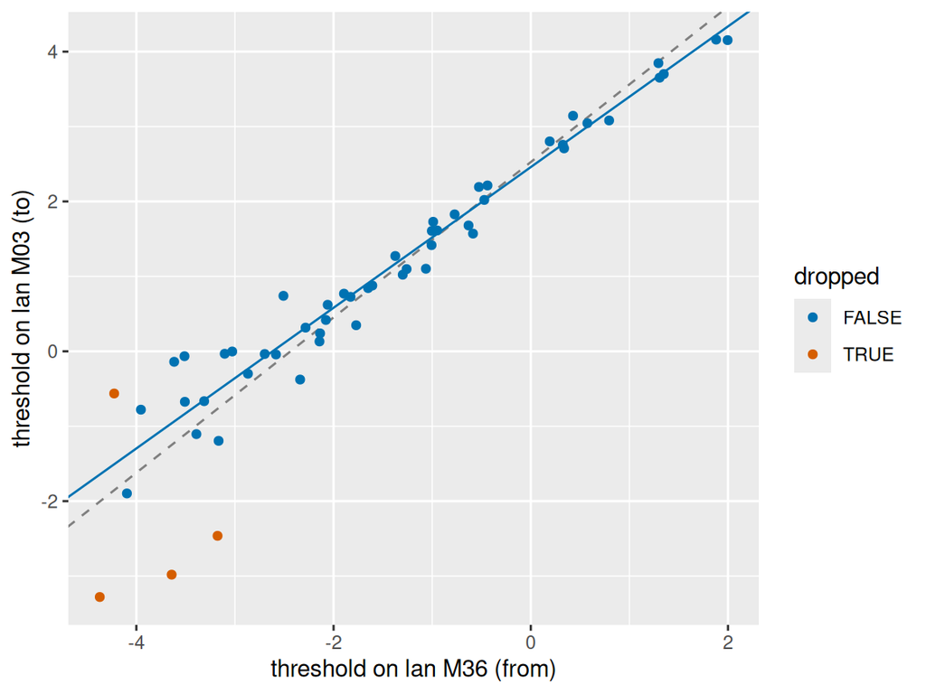

```r
ggplot(link_line$points, aes(from, to)) +
  geom_abline(intercept = B0, slope = A0, colour = "#7F7F7F", linetype = "dashed") +
  geom_abline(intercept = B, slope = A, colour = "#0072B2") +
  geom_point(aes(colour = dropped)) +
  scale_colour_manual(values = c(`FALSE` = "#0072B2", `TRUE` = "#D55E00")) +
  labs(x = "threshold on lan M36 (from)", y = "threshold on lan M03 (to)")
```

`plot(link_line)` 畫同樣的圖，再加上篩選帶。 點排成曲線而不是直線時，這條連結就不能照用。

### 3.6 其他的篩選規則

預設是 `spread = "sd"`、`unit = "step"`。 `spread = "mad"` 用穩健的分散（`stats::mad()`），離群的點不會把篩選的範圍撐大；`spread = "se"` 用每個點自己的 SE。 `unit = "item"`：一題有一個步驟被標出來，這一題的所有步驟都拿掉。

$$\text{mad: } |e_j| > \mathit{cut}\cdot 1.4826\,\mathrm{MAD}(e);\qquad
\text{se: } \frac{|e_j|}{\sqrt{\mathit{se}_{to,j}^2 + A_0^2\,\mathit{se}_{from,j}^2}} > \mathit{cut}$$

```latex
\text{mad: } |e_j| > \mathit{cut}\cdot 1.4826\,\mathrm{MAD}(e);\qquad
\text{se: } \frac{|e_j|}{\sqrt{\mathit{se}_{to,j}^2 + A_0^2\,\mathit{se}_{from,j}^2}} > \mathit{cut}
```

```r
rules <- tibble(spread = c("sd", "mad", "se", "sd"), unit = c("step", "step", "step", "item"))
by_algo <- map2(rules$spread, rules$unit, \(s, u) {
  algo_screen(from, to, points$item, spread = s, unit = u,
              se_from = points$se_from, se_to = points$se_to)$dropped
})
by_kits <- map2(rules$spread, rules$unit, \(s, u) {
  kits_link_screen(points, spread = s, unit = u)$dropped
})
mutate(rules, n_dropped = map_int(by_algo, sum), same = map2_lgl(by_algo, by_kits, identical))
```

```
#> # A tibble: 4 × 4
#>   spread unit  n_dropped same
#>   <chr>  <chr>     <int> <lgl>
#> 1 sd     step          4 TRUE
#> 2 mad    step         10 TRUE
#> 3 se     step         25 TRUE
#> 4 sd     item          6 TRUE
```

### 3.7 教學程式

教學程式是 `link.R`。 它的示範是第 5 節的 D 連結（語言和動作接到錨題）；兩個校準之間的連結在 `slope` 段（第 8 節）。 `line` 段就是第 2、3 節：

```r
show_part("link.R", "line")
# ==== part: line ====
# 2 mean/sigma: slope = SD(to) / SD(from), intercept = mean(to) - slope mean(from)
mean_sigma <- function(from, to) {
  slope <- sd(to) / sd(from)
  c(intercept = mean(to) - slope * mean(from), slope = slope)
}

# 3 Screening once: the line through all points, e = to - (intercept0 + slope0 from); drop the
#   points with |e| > cut SD(e), then the line through the kept points
#   (kits_link_screen(spread = "mad") uses mad(e); unit = "item" drops every step of an item)
cut <- 2
screen <- function(from, to) {
  line0 <- mean_sigma(from, to)
  e <- to - (line0[["intercept"]] + line0[["slope"]] * from)
  if (sd(e) < 1e-8) return(rep(FALSE, length(e)))              # all on a line: nothing dropped
  abs(e) > cut * sd(e)
}
dropped <- screen(points$from, points$to)
line <- mean_sigma(points$from[!dropped], points$to[!dropped])
line
points$id[dropped]

# Convert (kits_convert()): new = intercept + slope x old, new SE = slope x old SE
line[["intercept"]] + line[["slope"]] * c(-2, 0, 2)
```

整份程式在乾淨的環境裡跑一次（約 10 秒），看它自己的 `compare` 段：

```r
env_link <- run_script("link.R")
env_link$diffs
```

```
#>    line   error domains slope_s
#>       0       0       0       0
```

## 4 連結誤差：整題重抽

### 4.1 這一步要做什麼

換一組共同題，線會變一點。 連結誤差回答：「如果共同題換一組，截距和斜率會差多少？」 做法是重抽題目：每次從共同題中抽回同樣多的題（可以重複），重做第 2、3 步。 同一題的步驟彼此相關，所以一題的所有步驟一起抽。 每次重抽都重新篩，所以連結誤差也包括「篩掉哪些點」的不確定性。

### 4.2 公式

$$\mathrm{SE}(B) = \mathrm{SD}_{r=1..R}\big(B^{(r)}\big),\qquad
\mathrm{SE}(A) = \mathrm{SD}_{r=1..R}\big(A^{(r)}\big)$$

```latex
\mathrm{SE}(B) = \mathrm{SD}_{r=1..R}\big(B^{(r)}\big),\qquad
\mathrm{SE}(A) = \mathrm{SD}_{r=1..R}\big(A^{(r)}\big)
```

- $r$ 是一次重抽，$R$ 是重抽的次數（`n_boot`）。
- 點太少、算不出線的重抽不算，另外數（`n_failed`）。
- 這裡用 $R = 200$，幾秒就好；報告用 2000。
- 截距和斜率的共變異數矩陣（`vcov`）第 7 節會用。

### 4.3 手算

一次重抽的線：篩一次，再畫線（第 2、3 節的手算，寫成一個函數）。

```r
link_once <- function(f, t) {
  if (length(f) < 3 || sd(f) == 0 || sd(t) == 0) return(c(intercept = NA, slope = NA))
  a0 <- sd(t) / sd(f)
  r <- t - (mean(t) - a0 * mean(f)) - a0 * f
  keep <- !(abs(r) > 2 * sd(r))
  if (sum(keep) < 3) return(c(intercept = NA, slope = NA))
  a <- sd(t[keep]) / sd(f[keep])
  c(intercept = mean(t[keep]) - a * mean(f[keep]), slope = a)
}
```

每題的點在哪幾列；一次抽題，就是抽這些列：

```r
items <- unique(points$item)
rows <- split(seq_along(points$item), factor(points$item, levels = items))
length(items)
```

```
#> [1] 18
```

200 次重抽，種子 1（和 kits 的預設相同）：

```r
set.seed(1)
draws <- t(replicate(200, {
  i <- unlist(rows[sample(items, replace = TRUE)], use.names = FALSE)
  link_once(from[i], to[i])
}))
c(intercept_error = sd(draws[, "intercept"]), slope_error = sd(draws[, "slope"]))
```

```
#> intercept_error     slope_error
#>       0.0824417       0.1045803
```

### 4.4 用 kits

`algo_link_error()` 接在 `algo_screen()` 後面，用同樣的點和篩選規則：

```r
err <- screen |>
  algo_link_error(n_boot = 200, seed = 1)
c(draws = identical(unname(err$draws), unname(draws)),
  intercept_error = identical(err$intercept_error, sd(draws[, "intercept"])),
  vcov = identical(unname(err$vcov), unname(cov(draws))))
```

```
#>           draws intercept_error            vcov
#>            TRUE            TRUE            TRUE
```

```r
err$n_failed
```

```
#> [1] 0
```

`n_failed` 是算不出線的重抽：這裡一次都沒有。

`kits_link_error()` 是第 4 步，接在 `kits_link_line()` 後面：

```r
co_steps <- link_line |>
  kits_link_error(n_boot = 200)
c(draws = identical(co_steps$draws, err$draws),
  slope_error = identical(co_steps$slope_error, err$slope_error))
```

```
#>       draws slope_error
#>        TRUE        TRUE
```

四步接起來，就是 `kits_linking()`；兩者只差記下來的那一行呼叫：

```r
co <- kits_linking(item36, item03, n_boot = 200)
identical(without_call(co), without_call(co_steps))
```

```
#> [1] TRUE
```

```r
co
```

```
#> <kits_link> new value = intercept + slope x old value
#>   scales: lan M36 -> lan M03
#>   intercept = 2.46  (linking error 0.08)
#>   slope     = 0.94  (linking error 0.10)
#>   points from: every common item step
#>   points: 54 (items: 18); dropped: 4 (lanc01:1, lanc01:2, lanc01:3, lanc04:1)
#>   before screening: intercept 2.53, slope 1.04; screening: |e| > 2 SD(e)
#> Next: kits_convert(scores, x), plot(x), summary(x, theta = ), confint(x).
#> Checks: OK
```

### 4.5 教學程式

`link.R` 的 `error` 段：

```r
show_part("link.R", "error")
# ==== part: error ====
# 4 Linking error: resample whole items n_boot times and redo the screening and the line; a draw
#   that cannot be fitted (fewer than 3 points, or one value only) is left out and counted
n_boot <- 200
seed <- 1
link_once <- function(from, to) {
  if (length(from) < 3 || sd(from) == 0 || sd(to) == 0) return(c(intercept = NA, slope = NA))
  drop <- screen(from, to)
  if (sum(!drop) < 3) return(c(intercept = NA, slope = NA))
  mean_sigma(from[!drop], to[!drop])
}

items <- unique(points$item)
rows <- split(seq_len(nrow(points)), factor(points$item, levels = items))
set.seed(seed)
draws <- t(replicate(n_boot, {
  i <- unlist(rows[sample(items, replace = TRUE)], use.names = FALSE)
  link_once(points$from[i], points$to[i])
}))
ok <- is.finite(draws[, "intercept"]) & is.finite(draws[, "slope"])
c(intercept_error = sd(draws[ok, "intercept"]), slope_error = sd(draws[ok, "slope"]),
  n_failed = sum(!ok))
# Between two calibrations kits also compares the slope with 1 (a PCM link needs only a shift;
#   Kolen & Brennan, 2014, p. 229): a note when |(slope - 1) / slope_error| > 2

# 5 The linking error at theta: the SD of intercept + slope theta over the draws (Kolen &
#   Brennan, 2014, pp. 249-252)
V_draws <- cov(draws[ok, ])
se_link <- function(theta) {
  sqrt(V_draws[1, 1] + theta^2 * V_draws[2, 2] + 2 * theta * V_draws[1, 2])
}
se_link(c(-2, 0, 2))
```

`set.seed(seed)` 和 kits 用同一個種子，所以重抽的結果相同。 最後的 `se_link()` 是第 7 節的公式：`V_draws` 是截距和斜率的共變異數矩陣。

## 5 接到 D：錨題和 domain check

### 5.1 這一步要做什麼

錨題是和 GSED 相同的題目，`tau` 是 GSED 的難度，單位是 D。 GSED 的題目是通過、沒通過，所以每個錨題只用一個步驟：通過步驟 $s$（預設 1，也就是至少 1 分）。 `tau` 是 RP50 的值（一半的孩子通過的 D），所以點也用 RP50 的門檻。 每個領域的錨題很少，所以幾個領域共用一條線（這裡是語言和動作）。

用錨題接到 D，是把 KIT 的量尺對齊到 GSED 的 D（Kolen & Brennan, 2014, pp. 493-500）。 等化要求構念、母群和施測條件都相同，這裡不是，所以叫校準（calibration）或量尺對齊（scale aligning）。 換算後的 D 能怎麼解釋，要看 KIT 和 GSED 有多相似。

### 5.2 公式

點：

$$(\mathit{from}_i,\ \mathit{to}_i) = \big(\mathit{thr}_{is},\ \tau^{\mathrm{GSED}}_i\big)$$

```latex
(\mathit{from}_i,\ \mathit{to}_i) = \big(\mathit{thr}_{is},\ \tau^{\mathrm{GSED}}_i\big)
```

線、篩選、重抽都和第 2–4 節相同。 domain check 多看一件事：如果每個領域可以有自己的截距 $B_d$，但共用一個斜率 $A_s$，各領域的截距差多少？

$$A_s = \sqrt{\frac{\sum (\mathit{to} - \overline{\mathit{to}}_d)^2}{\sum (\mathit{from} - \overline{\mathit{from}}_d)^2}},\qquad
B_d = \overline{\mathit{to}}_d - A_s\,\overline{\mathit{from}}_d$$

```latex
A_s = \sqrt{\frac{\sum (\mathit{to} - \overline{\mathit{to}}_d)^2}{\sum (\mathit{from} - \overline{\mathit{from}}_d)^2}},\qquad
B_d = \overline{\mathit{to}}_d - A_s\,\overline{\mathit{from}}_d
```

- $d$ 是領域；$\overline{\mathit{to}}_d$、$\overline{\mathit{from}}_d$ 是領域 $d$ 留下的點的平均。
- 加總是所有留下的點，每個點減去自己領域的平均。
- $A_s$ 只用來檢查，不是連結的斜率 $A$。 各領域的 $B_d$ 和共同的截距 $B$ 很接近，就支持共用一條線。

### 5.3 手算：點

兩個領域的門檻放在一起，留下通過步驟，接上 `tau`：

```r
thresholds <- bind_rows(lan = as_tibble(coef(item03)), motor = as_tibble(coef(item_motor)),
                        .id = "domain")
hand_anchor <- thresholds |>
  filter(item_score == 1) |>
  inner_join(select(kitm03$anchors, item_id, tau), by = "item_id") |>
  arrange(item_id)
count(hand_anchor, domain)
```

```
#> # A tibble: 2 × 2
#>   domain     n
#>   <chr>  <int>
#> 1 lan        2
#> 2 motor     25
```

### 5.4 用 kits：點和線

兩個校準放進一個有名字的 list；名字就是領域：

```r
domains <- list(lan = item03, motor = item_motor)
anchor_points <- kits_link_points(domains, kitm03$anchors)
c(from = identical(anchor_points$from, hand_anchor$thr),
  to = identical(anchor_points$to, hand_anchor$tau),
  domain = identical(anchor_points$domain, hand_anchor$domain))
```

```
#>   from     to domain
#>   TRUE   TRUE   TRUE
```

四步接起來，和一次呼叫比：

```r
d_steps <- anchor_points |>
  kits_link_screen() |>
  kits_link_line() |>
  kits_link_error(n_boot = 200)
d_link <- kits_linking(list(lan = item03, motor = item_motor), kitm03$anchors, n_boot = 200)
identical(without_call(d_link), without_call(d_steps))
```

```
#> [1] TRUE
```

```r
d_link
```

```
#> <kits_link> new value = intercept + slope x old value
#>   scales: lan M03, motor M03 -> D
#>   intercept = 64.44  (linking error 1.87)
#>   slope     = 7.17  (linking error 0.37)
#>   points from: the pass step of each anchor item (score >= 1), tau of dscore key gsed2406
#>   points: 27 (items: 27); dropped: 3 (bodyag10, bodybg01, bodybg04)
#>   before screening: intercept 63.48, slope 7.04; screening: |e| > 2 SD(e)
#>   kept points by domain: motor 22 (92%), lan 2 (8%)
#>   domain check: one slope shared by the domains, fitted with domain intercepts (kept points);
#>   it is not the slope of the line above:
#>  domain  n intercept slope
#>     lan  2     65.28  7.16
#>   motor 22     64.35  7.16
#> Next: kits_convert(scores, x), plot(x), summary(x, theta = ), confint(x).
#> Checks: 2 notes (see summary() or kits_check())
```

### 5.5 手算：domain check

留下的點，每個點減去自己領域的平均：

```r
kept <- as_tibble(d_link$points) |>
  filter(!dropped) |>
  mutate(dx = from - mean(from), dy = to - mean(to), .by = domain)
A_s <- sqrt(sum(kept$dy^2) / sum(kept$dx^2))
```

每個領域的截距，和 kits 的 `domains` 表比：

```r
hand_domains <- kept |>
  summarise(n = n(), intercept = mean(to) - A_s * mean(from), .by = domain) |>
  arrange(domain)
c(slope_s = identical(A_s, d_link$domains$slope[1]),
  intercept_d = isTRUE(all.equal(hand_domains$intercept, d_link$domains$intercept,
                                 tolerance = 1e-12)))
```

```
#>     slope_s intercept_d
#>        TRUE        TRUE
```

截距用 `all.equal()`（容許誤差 $10^{-12}$）：kits 的平均和這裡的加總順序不同，最後一位可能差一點。 這份示範資料的語言只有 2 題錨題，所以語言的 $B_d$ 只靠 2 個點，看看就好。

### 5.6 教學程式

`link.R` 的 `points` 段和 `domains` 段（3.7 節已經跑過，`compare` 段的 `domains`、`slope_s` 是 0）：

```r
show_part("link.R", "points")
# ==== part: points ====
# 1 One point per anchor item: the threshold of its pass step (score >= 1) on the KIT scale
#   (from) and its tau on D (to); the items in the order of sort()
points <- thresholds |>
  filter(item_score == 1) |>
  inner_join(select(anchors, item_id, tau), by = "item_id") |>
  arrange(item_id) |>
  transmute(id = item_id, item = item_id, from = thr, to = tau, domain)
points
# Between two calibrations (kits_linking(item36, item03)) each common step is a point instead:
#   inner_join() the two threshold tables by item_id and item_score; from = thr of M36, to = M03

show_part("link.R", "domains")
# ==== part: domains ====
# 6 Domain check: on the kept points, one slope slope_s shared by the domains with an intercept
#   intercept_d per domain (it is not the slope of the line above)
kept <- points |>
  filter(!dropped) |>
  mutate(dx = from - mean(from), dy = to - mean(to), .by = domain)
slope_s <- sqrt(sum(kept$dy^2) / sum(kept$dx^2))
domains <- kept |>
  summarise(n = n(), intercept = mean(to) - slope_s * mean(from), .by = domain) |>
  arrange(domain)
domains
```

## 6 換算：`kits_convert()`

### 6.1 這一步要做什麼

有了線，就能把分數從一條量尺換到另一條。 $\theta$ 照線換；SE 只乘上斜率（平移不改變誤差的大小）。 幾條連結可以接著用：M36 → M03 → D。 兩條直線接起來還是一條直線。

### 6.2 公式

$$\theta^* = B + A\,\theta,\qquad \mathrm{SE}^* = A\,\mathrm{SE}$$

```latex
\theta^* = B + A\,\theta,\qquad \mathrm{SE}^* = A\,\mathrm{SE}
```

先用連結 1，再用連結 2：

$$A = A_2 A_1,\qquad B = B_2 + A_2 B_1$$

```latex
A = A_2 A_1,\qquad B = B_2 + A_2 B_1
```

### 6.3 手算

M36 的分數（在 lan M36 的量尺上）：

```r
persons36 <- distinct(lan36, visit_id, cohort, wave_m, age_m, sex)
raw36 <- kits_subj(lan36, item36, persons = persons36)
theta_03 <- co$intercept + co$slope * raw36$theta
se_03 <- co$slope * raw36$se
```

再接到 D，以及合起來的一條線：

```r
theta_D <- d_link$intercept + d_link$slope * theta_03
B_chain <- d_link$intercept + d_link$slope * co$intercept
A_chain <- d_link$slope * co$slope
c(intercept = B_chain, slope = A_chain)
```

```
#> intercept     slope
#> 82.064927  6.727683
```

### 6.4 用 kits

`kits_` 這一層：`kits_convert()` 照順序套用連結，並檢查量尺。

```r
s03 <- raw36 |>
  kits_convert(co)
sD <- raw36 |>
  kits_convert(co, d_link)
c(theta = identical(s03$theta, theta_03), se = identical(s03$se, se_03),
  theta_D = identical(sD$theta, theta_D))
```

```
#>   theta      se theta_D
#>    TRUE    TRUE    TRUE
```

`algo_` 這一層：`algo_line()` 套用一條線，或把一串線合成一條。

```r
chain <- algo_line(list(co, d_link))
c(one = identical(algo_line(co, x = raw36$theta), theta_03),
  two = identical(algo_line(d_link, x = algo_line(co, x = raw36$theta)), theta_D),
  chain = identical(c(chain$intercept, chain$slope), c(B_chain, A_chain)))
```

```
#>   one   two chain
#>  TRUE  TRUE  TRUE
```

用合起來的一條線一次換，和一條一條換，只差浮點運算的順序：

```r
all.equal(algo_line(chain, x = raw36$theta), sD$theta, tolerance = 1e-12)
```

```
#> [1] TRUE
```

`summary(sD)$conversion` 也列出這一串連結和合起來的線。 順序錯了（先接 D 再接 M03），kits 會停下來：

```r
tryCatch(kits_convert(raw36, d_link, co), kits_error_scale = \(e) conditionMessage(e))
```

```
#> [1] "`x` is on scale lan M36, but link 1 converts lan M03, motor M03 -> D. The links given: lan M03, motor M03 -> D, then lan M36 -> lan M03. Give the links in order, starting with a link from lan M36."
```

`algo_line()` 不記量尺，所以它不會檢查順序；這是兩層的分工。

### 6.5 教學程式

換算在分數的教學程式 `wle.R` 的 `convert` 段（02_scoring 讀整份）：

```r
show_part("wle.R", "convert")
# ==== part: convert ====
# 8 Converted scores, kits_convert(scores, link): the line of a link (link.R) on each score,
#   new theta = intercept + slope theta, new SE = slope SE. With the bootstrap draws of the link
#   (n_boot > 0), se_link is the SD of intercept + slope theta over the draws (at the old theta),
#   and se_total = sqrt(se^2 + se_link^2). Person fit and flag do not change.
convert <- function(subj, intercept, slope, draws) {
  V <- cov(draws)                                         # of the intercepts and slopes drawn
  subj |>
    mutate(se_link = sqrt(V[1, 1] + 2 * V[1, 2] * theta + V[2, 2] * theta^2),
           theta = intercept + slope * theta,
           se = slope * se,
           se_total = sqrt(se^2 + se_link^2))
}

# With kits: a link of these scores to the language scale of kitm36 (kits_linking(item, item36),
#   link.R), and the converted scores of kits_subj() (below 1e-6)
lan36 <- filter(kits::kitm36$responses, domain == "lan") |>
  pivot_wider(id_cols = visit_id, names_from = item_id, values_from = item_score)
X36 <- as.matrix(lan36[-1])
rownames(X36) <- lan36$visit_id
link <- kits::kits_linking(item, kits::kits_item(X36, scale = "lan M36"), n_boot = 200)
subj_36 <- convert(subj, link$intercept, link$slope, link$draws)
want_36 <- kits::kits_convert(kits::kits_subj(X, item), link)            # on lan M36
want_36 <- want_36[match(subj_36$visit_id, want_36$visit_id), ]
diffs_36 <- map_dbl(set_names(c("theta", "se", "se_link", "se_total")),
                   \(v) max(abs(subj_36[[v]] - want_36[[v]])))
diffs_36
```

## 7 每個 θ 的連結誤差：`se_link`、`se_total`

### 7.1 這一步要做什麼

連結誤差和分數的位置有關。 離共同題的中心越遠，斜率的誤差影響越大（Kolen & Brennan, 2014, pp. 249-252）。 所以每個 $\theta$ 有自己的連結誤差 `se_link`。 `se_total` 把孩子自己的測量誤差（`se`）和連結誤差合起來。

### 7.2 公式

一條線：$B_r + A_r\theta$ 在重抽之間的 SD。 線是直線，所以 delta method 的式子剛好等於這個 SD。

$$\mathrm{SE}_{\mathrm{link}}(\theta) = \mathrm{SD}_r(B_r + A_r\theta)
= \sqrt{\mathrm{Var}(B) + \theta^2\,\mathrm{Var}(A) + 2\theta\,\mathrm{Cov}(A, B)}$$

```latex
\mathrm{SE}_{\mathrm{link}}(\theta) = \mathrm{SD}_r(B_r + A_r\theta)
= \sqrt{\mathrm{Var}(B) + \theta^2\,\mathrm{Var}(A) + 2\theta\,\mathrm{Cov}(A, B)}
```

一串連結 $k = 1, \dots, K$：從 $m_0 = \theta$、$v_0 = 0$ 開始，一條一條走。

$$m_k = B_k + A_k m_{k-1},\qquad
v_k = \mathrm{Var}(B_k) + 2\,\mathrm{Cov}(A_k, B_k)\,m_{k-1} + \mathrm{Var}(A_k)\,(v_{k-1} + m_{k-1}^2) + A_k^2\,v_{k-1}$$

```latex
m_k = B_k + A_k m_{k-1},\qquad
v_k = \mathrm{Var}(B_k) + 2\,\mathrm{Cov}(A_k, B_k)\,m_{k-1} + \mathrm{Var}(A_k)\,(v_{k-1} + m_{k-1}^2) + A_k^2\,v_{k-1}
```

$$\mathit{se\_link} = \sqrt{v_K},\qquad \mathit{se\_total} = \sqrt{\mathit{se}^2 + \mathit{se\_link}^2}$$

```latex
\mathit{se\_link} = \sqrt{v_K},\qquad \mathit{se\_total} = \sqrt{\mathit{se}^2 + \mathit{se\_link}^2}
```

- Var、Cov 用 $n - 1$ 當分母，所以 $\theta = 0$ 時就是 `intercept_error`。
- 兩條連結用不同的題（共同題、錨題），所以把它們的重抽當成彼此獨立。 這是 Braun 和 Holland 的 delta method（Kolen & Brennan, 2014, p. 269），再加上一個小的乘積項 $\mathrm{Var}(A_k)\,v_{k-1}$。
- 中心放在估計的線上，所以分兩次換算和一次換算的 `se_link` 相同。
- `se_link` 只是「哪些題剛好是共同題或錨題」的抽樣誤差；它不含校準時孩子的抽樣誤差。

### 7.3 手算：一條線

四個 $\theta$（在 lan M36 的量尺上），直接算重抽之間的 SD，和用共變異數矩陣算：

```r
th <- c(-1, 0, 1, 2)
sd_at <- map_dbl(th, \(t) sd(co$draws[, "intercept"] + co$draws[, "slope"] * t))
V <- co$vcov
se_formula <- sqrt(V[1, 1] + th^2 * V[2, 2] + 2 * th * V[1, 2])
rbind(sd_over_draws = sd_at, formula = se_formula)
```

```
#>                     [,1]      [,2]      [,3]      [,4]
#> sd_over_draws 0.07318181 0.0824417 0.1735274 0.2744101
#> formula       0.07318181 0.0824417 0.1735274 0.2744101
```

### 7.4 手算：一串連結

一條連結的一步：從 $(m_{k-1}, v_{k-1})$ 到 $(m_k, v_k)$。

```r
next_link <- function(mv, l) {
  B_r <- l$draws[, "intercept"]
  A_r <- l$draws[, "slope"]
  v <- var(B_r) + 2 * cov(B_r, A_r) * mv$m + var(A_r) * (mv$v + mv$m^2) + l$slope^2 * mv$v
  list(m = l$intercept + l$slope * mv$m, v = v)
}
```

M36 的每個孩子，走過 M36 → M03 → D：

```r
mv <- list(m = raw36$theta, v = 0 * raw36$theta)
for (l in list(co, d_link)) mv <- next_link(mv, l)
se_link_hand <- sqrt(pmax(mv$v, 0))
se_total_hand <- sqrt(sD$se^2 + se_link_hand^2)
```

### 7.5 用 kits

`kits_convert()` 在每條連結都有重抽時，加上 `se_link` 和 `se_total` 兩欄：

```r
c(se_link = identical(sD$se_link, se_link_hand), se_total = identical(sD$se_total, se_total_hand))
```

```
#>  se_link se_total
#>     TRUE     TRUE
```

```r
as_tibble(sD) |>
  select(theta, se, se_link, se_total) |>
  head(4)
```

```
#> # A tibble: 4 × 4
#>   theta    se se_link se_total
#>   <dbl> <dbl>   <dbl>    <dbl>
#> 1  67.5  2.09    2.36     3.16
#> 2  93.8  3.86    3.64     5.30
#> 3 101.   2.21    4.35     4.87
#> 4 108.   2.62    5.06     5.70
```

一條線，選定的 $\theta$：放進一張有 `theta` 欄的表，用 `from` 說它在哪一條量尺上。

```r
at_th <- kits_convert(tibble(theta = th), co, from = "lan M36")
c(formula = identical(at_th$se_link, se_formula),
  sd_over_draws = isTRUE(all.equal(at_th$se_link, sd_at, tolerance = 1e-12)))
```

```
#>       formula sd_over_draws
#>          TRUE          TRUE
```

直接算 SD 和用公式算只差浮點的順序，所以用 `all.equal()`（$10^{-12}$）。 分兩次換算（先 `co`，再 `d_link`）也一樣：

```r
two_steps <- raw36 |>
  kits_convert(co) |>
  kits_convert(d_link)
all.equal(two_steps$se_link, sD$se_link, tolerance = 1e-12)
```

```
#> [1] TRUE
```

`algo_` 這一層沒有 `se_link`：它只需要每條線的 `draws`，上面的 `next_link()` 就是全部。 一條連結沒有重抽時（`n_boot = 0`），`kits_convert()` 不加這兩欄，並用訊息說是哪一條。

## 8 斜率和 1 比

### 8.1 這一步要做什麼

PCM 沒有鑑別度參數，所以兩個 PCM 校準之間，理論上只差一個平移（斜率 $A = 1$）。 Masters（1984）用 PCM 建題庫時，連結只用平移（Kolen & Brennan, 2014, p. 229）。 kits 還是保留 mean/sigma 的自由斜率，因為 KIT 的題目在不同年齡的鑑別力可能不同。 然後把 $A$ 和 1 比：差太多，表示量尺在兩次校準之間伸縮了，值得在報告裡說明。 自由斜率還是照用，診斷只是註記。

### 8.2 公式

$$z = \frac{A - 1}{\mathrm{SE}_{\mathrm{link}}(A)};\qquad \text{note if } |z| > 2$$

```latex
z = \frac{A - 1}{\mathrm{SE}_{\mathrm{link}}(A)};\qquad \text{note if } |z| > 2
```

- $\mathrm{SE}_{\mathrm{link}}(A)$ 是 `slope_error`（第 4 節）。
- 只有兩個校準之間的連結才比；接到錨題的連結兩邊單位不同（logit 和 D），不比。

### 8.3 手算

```r
z_hand <- (co$slope - 1) / sd(co$draws[, "slope"])
z_hand
```

```
#> [1] -0.5850319
```

### 8.4 用 kits

連結的診斷表有一列 `slope vs 1`：

```r
slope_z <- function(link) filter(as_tibble(link$diagnostics), check == "slope vs 1")$value
identical(slope_z(co), z_hand)
```

```
#> [1] TRUE
```

接到錨題的連結沒有這一列（長度 0）：

```r
length(slope_z(d_link))
```

```
#> [1] 0
```

`algo_` 這一層：`algo_link_error()` 的 `slope_error`，套進公式就是 $z$。

```r
identical((line$slope - 1) / err$slope_error, z_hand)
```

```
#> [1] TRUE
```

### 8.5 斜率不是 1 的例子

用 `kits_sim()` 模擬兩個世代，12 題兩點計分，第 5–8 題是共同題。 兩點計分的題只有一個步驟，門檻就是 $\beta$，所以容易看出預期的斜率。 年長的世代，題目的鑑別力都是 1.4：$\theta$ 和 $\beta$ 都乘上 1.4，等於把 PCM 的量尺拉長。

```r
betas <- set_names(as.list(seq(-3, 3, length.out = 12)), sprintf("q%02d", 1:12))
set.seed(3)
young <- kits_sim(rnorm(500, -0.5), betas[1:8], seed = 1)
old <- kits_sim(1.4 * rnorm(500, 0.5), map(betas[5:12], \(x) 1.4 * x), seed = 2)
```

年長世代的量尺是年輕世代的 1.4 倍，所以接回去的斜率應該接近 $1/1.4$：

```r
item_young <- kits_item(young, scale = "young")
item_old <- kits_item(old, scale = "old (wide)")
co_wide <- kits_linking(item_old, item_young, n_boot = 200)
c(slope = co_wide$slope, expected = 1 / 1.4, z = slope_z(co_wide))
```

```
#>      slope   expected          z
#>  0.6582245  0.7142857 -3.7757779
```

只有 4 個點，所以斜率離 $1/1.4$ 還有一段距離；但它離 1 超過 2 個連結誤差，診斷註記：

```r
as_tibble(co_wide$diagnostics) |>
  filter(check == "slope vs 1") |>
  select(check, value, status)
```

```
#> # A tibble: 1 × 3
#>   check      value status
#>   <chr>      <dbl> <chr>
#> 1 slope vs 1 -3.78 note
```

### 8.6 教學程式

`link.R` 的 `slope` 段：示範資料 M36 的語言接到 M03（就是這份教學的 `co`）。

```r
show_part("link.R", "slope")
# ==== part: slope ====
# 7 Between two calibrations, kits_linking(item36, item03): one point per common step, its
#   threshold on M36 (from) and on M03 (to), with the SE of both. Steps 2-4 are the same; the
#   slope is also compared with 1, z = (slope - 1) / slope_error, since a PCM link needs only a
#   shift (Kolen & Brennan, 2014, p. 229); kits notes |z| > 2. Here: the language items of kitm36

# With kits: the calibration of the language items of kitm36 (cml.R)
lan36 <- filter(kits::kitm36$responses, domain == "lan") |>
  tidyr::pivot_wider(id_cols = visit_id, names_from = item_id, values_from = item_score)
X36 <- as.matrix(lan36[-1])
rownames(X36) <- lan36$visit_id
item36 <- kits::kits_item(X36, scale = "lan M36")

points36 <- as.data.frame(coef(item36)) |>
  inner_join(filter(thresholds, domain == "lan"), by = c("item_id", "item_score"),
             suffix = c("_from", "_to")) |>
  arrange(item_id, item_score) |>
  transmute(id = paste0(item_id, ":", item_score), item = item_id, from = thr_from, to = thr_to,
            se_from = thr_se_from, se_to = thr_se_to)
dropped36 <- screen(points36$from, points36$to)
line36 <- mean_sigma(points36$from[!dropped36], points36$to[!dropped36])

# Resample whole items as in part error, then z
rows36 <- split(seq_len(nrow(points36)), factor(points36$item, levels = unique(points36$item)))
set.seed(seed)
draws36 <- t(replicate(n_boot, {
  i <- unlist(rows36[sample(names(rows36), replace = TRUE)], use.names = FALSE)
  link_once(points36$from[i], points36$to[i])
}))
slope_error36 <- sd(draws36[, "slope"], na.rm = TRUE)
z_slope <- (line36[["slope"]] - 1) / slope_error36
c(line36, slope_error = slope_error36, z = z_slope)

# With kits: the same link and its row "slope vs 1" (below 1e-6)
link36 <- kits::kits_linking(item36, item_lan, n_boot = n_boot)
z_kits <- filter(as.data.frame(link36$diagnostics), check == "slope vs 1")$value
diffs_slope <- c(line = max(abs(line36 - c(link36$intercept, link36$slope))),
                 z = abs(z_slope - z_kits))
diffs_slope
```

3.7 節跑過的程式算出同樣的線和 $z$：

```r
env_link$diffs_slope
```

```
#> line    z
#>    0    0
```

## 9 可重現的管線

下面三段貼進一個新的 R session，只要 `library(kits)`，就得到和這份教學完全相同的結果。 資料用 base R 的 `subset()`，不用 dplyr。

```r
library(kits)
lan03 <- subset(kitm03$responses, domain == "lan")
motor03 <- subset(kitm03$responses, domain == "motor")
lan36 <- subset(kitm36$responses, domain == "lan")
item03 <- kits_item(lan03, scale = "lan M03")
item_motor <- kits_item(motor03, scale = "motor M03")
item36 <- kits_item(lan36, scale = "lan M36")
```

連結：一次呼叫、四步的 `kits_` 管線、`algo_` 的積木。

```r
co <- kits_linking(item36, item03, n_boot = 200)
co_steps <- kits_link_points(item36, item03) |>
  kits_link_screen() |>
  kits_link_line() |>
  kits_link_error(n_boot = 200)
pts <- kits_link_points(item36, item03)
line <- algo_screen(pts$from, pts$to, pts$item) |>
  algo_mean_sigma()
err <- algo_screen(pts$from, pts$to, pts$item) |>
  algo_link_error(n_boot = 200)
```

換算：M36 的分數接到 M03，再接到 D。

```r
d_link <- kits_linking(list(lan = item03, motor = item_motor), kitm03$anchors, n_boot = 200)
persons36 <- unique(lan36[c("visit_id", "cohort", "wave_m", "age_m", "sex")])
sD <- lan36 |>
  kits_subj(item36, persons = persons36) |>
  kits_convert(co, d_link)
```

這份教學真的開一個新的 R session（`callr::r()`）跑這三段，再把結果帶回來比：

```r
code <- unlist(map(c("repro-data", "repro-link", "repro-convert"), knitr::knit_code$get))
fresh <- callr::r(function(code) {
  env <- new.env()
  eval(parse(text = code), envir = env)
  as.list(env)
}, args = list(code = code))
```

```r
c(co = identical(fresh$co, co), d_link = identical(fresh$d_link, d_link),
  steps = identical(without_call(fresh$co_steps), without_call(co)),
  line = identical(c(fresh$line$intercept, fresh$line$slope), c(co$intercept, co$slope)),
  error = identical(fresh$err$draws, co$draws),
  theta = identical(fresh$sD$theta, sD$theta), se_link = identical(fresh$sD$se_link, sD$se_link))
```

```
#>      co  d_link   steps    line   error   theta se_link
#>    TRUE    TRUE    TRUE    TRUE    TRUE    TRUE    TRUE
```

- `co` 和 `d_link` 連記下來的呼叫都相同，因為那一行字一樣。
- 四步的管線和 `kits_linking()` 只差那一行字（`without_call()`）。
- `algo_` 的積木給同樣的線和同樣的重抽，但不記量尺，也沒有診斷。

## 10 整理

| 步驟 | 公式 | `kits_` | `algo_` | 教學程式 |
| --- | --- | --- | --- | --- |
| 點 | $(\mathit{thr}_{ik}, \mathit{thr}_{ik})$ 或 $(\mathit{thr}_{is}, \tau_i)$ | `kits_link_points()` | （兩個向量） | `link.R` `points` |
| mean/sigma | $A = \mathrm{SD}(\mathit{to})/\mathrm{SD}(\mathit{from})$ | 在 `kits_link_screen()`、`kits_link_line()` 裡 | `algo_mean_sigma()` | `line` |
| 篩一次 | $\|e_j\| > \mathit{cut}\,\mathrm{SD}(e)$ | `kits_link_screen()` | `algo_screen()` | `line`、`rules` |
| 連結誤差 | $\mathrm{SD}_r(B_r)$、$\mathrm{SD}_r(A_r)$ | `kits_link_error()` | `algo_link_error()` | `error` |
| domain check | $A_s$、$B_d$ | `kits_link_line()` 的 `domains` | （手算） | `domains` |
| 換算 | $\theta^* = B + A\theta$ | `kits_convert()` | `algo_line()` | `wle.R` `convert` |
| `se_link` | $m_k$、$v_k$ | `kits_convert()` | （`draws` + 手算） | `error` |
| 斜率和 1 比 | $z = (A - 1)/\mathrm{SE}(A)$ | `link$diagnostics` | `slope_error` | `slope` |

一個新的波次要用固定參數校準之前，先看哪些題變了（`kits_drift()`）。 它用的是同一條篩過一次的 mean/sigma 線；見 05_checks。

全部算完的時間：

```r
round(difftime(Sys.time(), t_start, units = "secs"))
```

```
#> Time difference of 43 secs
```

**下一步：** 04_norms：用換算好的 D 做常模。

## 參考文獻

- Kolen, M. J., & Brennan, R. L. (2014). *Test equating, scaling, and linking* (3rd ed.). Springer. doi:10.1007/978-1-4939-0317-7
- Marco, G. L. (1977). Item characteristic curve solutions to three intractable testing problems. *Journal of Educational Measurement, 14*(2), 139-160. doi:10.1111/j.1745-3984.1977.tb00033.x
- Masters, G. N. (1984). Constructing an item bank using partial credit scoring. *Journal of Educational Measurement, 21*(1), 19-32. doi:10.1111/j.1745-3984.1984.tb00218.x
- Weber, A. M., Rubio-Codina, M., Walker, S. P., van Buuren, S., Eekhout, I., et al. (2019). The D-score: a metric for interpreting the early development of infants and toddlers across global settings. *BMJ Global Health, 4*(6), e001724. doi:10.1136/bmjgh-2019-001724
- R Core Team (2026). *R: A language and environment for statistical computing*. R Foundation for Statistical Computing, Vienna, Austria. https://www.R-project.org/